# R-based web apps with Shiny

Mik Black

7 February 2018

## Overview

This lesson works through a series of steps to create a simple web-based interface using the R shiny package.

Install shiny via:

```r
install.packages('shiny')
```

## RStudio links

The RStudio website provides a lot of information on how to use shiny:

- http://shiny.rstudio.com/
- http://shiny.rstudio.com/tutorial/

They also provide a gallery of shiny apps:

- http://shiny.rstudio.com/gallery/

## What does shiny do?

The shiny packages allows users to create incricate (or simple) interactive web pages for data analysis and/or visualisation.

All code is written in R, so there is no need to use web-specific tools such as javascript or CSS.

Over the past three years, shiny has become an incredibly popular tool for generating interactive web pages, and a huge number of powerful and compelling interfaces have been created.

## Shiny components

Two options:

- Two files (older way to do things):
- `ui.R` defines the user interface (i.e., how the user will interact with the web page).
- `server.R` defines the content (i.e., the data, visualisations and analyses the user will be interacting with)
- Single file (more recent):
- `app.R` contains the information for both the user interface and the content.
- within the `app.R` file, this information is stored as `ui` and `server` objects.

The tutorial on the RStudio site provides example code for a simple shiny app:

http://shiny.rstudio.com/tutorial/written-tutorial/lesson1/

We’re going to simplify even further - rather than start with an existing app, we’ll generate some plots in R, and then figure out how to place them within a shiny app.

Once we’ve got a basic interface in place, we’ll gradually add elements to extend the functionality.

## Example ui code

Taken from: http://shiny.rstudio.com/tutorial/written-tutorial/lesson1/

```r
library(shiny)

# Define UI for app that draws a histogram ----
ui <- fluidPage(

  # App title ----
  titlePanel("Hello Shiny!"),

  # Sidebar layout with input and output definitions ----
  sidebarLayout(

    # Sidebar panel for inputs ----
    sidebarPanel(

      # Input: Slider for the number of bins ----
      sliderInput(inputId = "bins",
                  label = "Number of bins:",
                  min = 1,
                  max = 50,
                  value = 30)

    ),

    # Main panel for displaying outputs ----
    mainPanel(

      # Output: Histogram ----
      plotOutput(outputId = "distPlot")

    )
  )
)
```

## Example server code

Taken from: http://shiny.rstudio.com/tutorial/written-tutorial/lesson1/

```r
# Define server logic required to draw a histogram ----
server <- function(input, output) {

  # Histogram of the Old Faithful Geyser Data ----
  # with requested number of bins
  # This expression that generates a histogram is wrapped in a call
  # to renderPlot to indicate that:
  #
  # 1. It is "reactive" and therefore should be automatically
  #    re-executed when inputs (input$bins) change
  # 2. Its output type is a plot
  output$distPlot <- renderPlot({

    x    <- faithful$waiting
    bins <- seq(min(x), max(x), length.out = input$bins + 1)

    hist(x, breaks = bins, col = "#75AADB", border = "white",
         xlab = "Waiting time to next eruption (in mins)",
         main = "Histogram of waiting times")

    })

}
```

## Can we make it more simple?

Start with the “cars” data set from base R:

```r
data(cars)
dim(cars)
```

```
## [1] 50  2
```

```r
head(cars)
```

```
##   speed dist
## 1     4    2
## 2     4   10
## 3     7    4
## 4     7   22
## 5     8   16
## 6     9   10
```

## What might we like to plot?

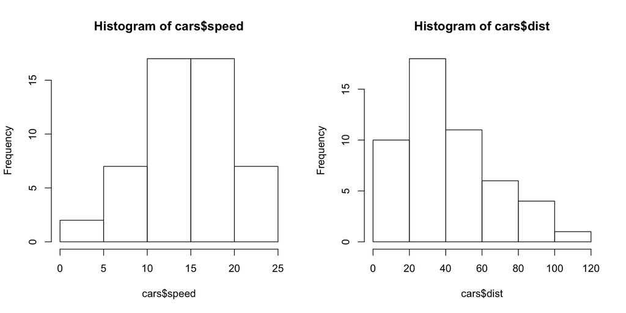

```r
par(mfrow=c(1,2))
hist(cars$speed)
hist(cars$dist)
```

## Different syntax

Remember that we can also specify columns via: `hist(cars[,"speed"])` which will come in handy later:

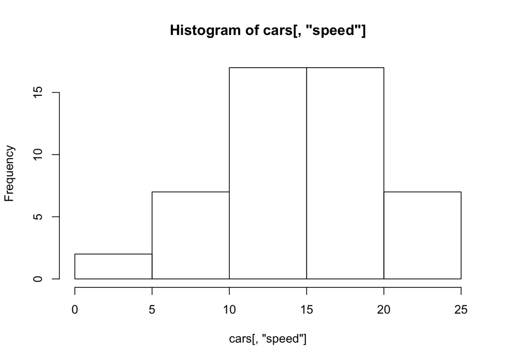

```r
hist(cars[ , "speed"])
```

## Creating a VERY basic shiny app: content

`server` object:

```r
## Create the function to be excuted by shiny
server <- shinyServer(function(input, output) {

  ## Define an object called "main_plot" that will be drawn
  ## by the "renderPlot" function
  output$main_plot <- renderPlot({

    ## Specify the plot that will be generated
    hist(cars[,"speed"])
  })

})
```

## Creating a VERY basic shiny app: interface

Initially we have no need for an interface - the plot we are generating is fixed.

`ui` object:

```r
ui <- fluidPage(

  ## Tell shiny what to plot - the "main_plot" object
  ## associated with "output" generated
  ## by the server.R file
  plotOutput(outputId = "main_plot")

)
```

## Defining ui and server for Shiny

The final part of the `app.R` file tells the `Shiny` package about the `ui` and `server` components:

```r
# Run the application
shinyApp(ui = ui, server = server)
```

This is placed at the bottom of the `app.R` file, after the `ui` and `server` objects have been defined.

## Running the app

Create a directory called “carsApp”, and place the `app.R` file in that directory (i.e., copy and paste the code above into a file called `app.R` in a directory called “carsApp”). You’ll also need to load the `cars` data set. To do this, add the following lines to the top of the `app.R` file:

```r
## Load the "cars" data set
data(cars)
```

In R, load the shiny package, and run the app:

```r
library(shiny)
runApp('carsApp')
```

If you are working in RStudio, the `runApp()` command will open your app in a built-in web browser, otherwise it will open in your usual system browser (e.g., Firefox).

## That app is boring!! (and ugly)

All the `runApp()` command did was create an ugly plot in a web browser.

We won’t fix the “ugly” just yet, but lets add some interactivity.

## Adding interactivity: ui.R

Add an option to choose which variable to plot (speed or dist).

First update the interface:

```r
ui <- fluidPage(

  ## Add a pull-down menu to allow selection of
  ## the variable to be plotted
  selectInput(inputId = "plot_var",
              label = "Variable to plot",
              choices = c("speed", "dist"),
              selected = "speed"),

  ## Tell shiny what to plot - the "main_plot" object
  ## associated with "output" generated
  ## by the server.R file
  plotOutput(outputId = "main_plot")

)
```

Then modify the server.R file to accommodate the new information. Specifically, we edit the line:

```r
hist(cars[,"speed"])
```

and replace it with

```r
hist(cars[,input$plot_var])
```

This tells the `hist` command to plot the data specified by `plot_var` from the `input` object (specified in ui.R).

The `server` object code becomes:

```r
## Create the function to be excuted by shiny
server <- function(input, output) {

  ## Define an object called "main_plot" that will be drawn
  ## by the "renderPlot" function
  output$main_plot <- renderPlot({

    ## Specify the plot that will be generated
    hist(cars[,input$plot_var])
  })

}
```

## Test the new app

```r
runApp('carsApp')
```

Now we’ve got some interactivity! Time to work on the “ugly”…

## Change the page style

We’ve started with the most basic shiny framework for a webpage.

By changing the details in the ui.R file, we can change the layout (and look) of our interface.

A common approach to application design is to provide a “side bar” on the left of the screen for users to interact with - this then alters the content being displayed on the right.

Edit the `ui` object code:

```r
ui <- fluidPage(

  ## Give the application a title
  headerPanel("My awesome plotting app"),

  ## Put the input controls in a sidebar panel
  sidebarPanel(

  ## Add a pull-down menu to allow selection of
  ## the variable to be plotted
  selectInput(inputId = "plot_var",
              label = "Variable to plot",
              choices = c("speed", "dist"),
              selected = "speed")
  ),

  ## Tell shiny what to plot - the "main_plot" object
  ## associated with "output" generated
  ## by the server.R file
  mainPanel(

    ## Give the panel a name
    h4("Plot of cars data"),

    plotOutput(outputId = "main_plot")
  )

)
```

Lets see how our updated app looks:

```r
runApp('carsApp')
```

## Lets get some more interactivity

Add the following to the `ui` object code below the current `selectInput` statement:

```r
sliderInput(inputId = "nbins",
            label = "Number of bins",
            min=2,
            max=15,
            value=10,
            round=TRUE)
```

Note that you’ll need to add a comma to the last line of the `selectInput`, that is:

```r
selected = "speed"),
```

Now we need to update the `server` object code to use this new information. Replace the line:

```r
hist(cars[,input$plot_var])
```

with

```r
hist(cars[,input$plot_var], breaks = input$nbins)
```

Run the app, and see what happens!

```r
runApp('carsApp')
```

## Getting fancier - adding tabs:

Create something new to plot in `server` (add below the existing plotting code):

```r
  ## Define a second plot
  output$second_plot <- renderPlot({

      ## Specify the plot that will be generated
      boxplot(cars[,input$plot_var])
  })
```

Now alter the “mainPanel” section of `ui` to add information about tabs:

```r
  mainPanel(

    ## Add tabs
    tabsetPanel(

      ## Define a tab for the histogram
      tabPanel(
        h4("Plot of cars data"),
        plotOutput(outputId = "main_plot")
      ),

     ## And a tab for the boxplot
      tabPanel(
        h4("Boxplot of cars data"),
        plotOutput(outputId = "second_plot")
      )

    )
  )
```

Note that the `outputId` defined in the `server` object code is being used to determine which output to include on each tab.

Run the app - this is getting cooler.

```r
runApp('carsApp')
```

## Conditioning

Shiny also provides the ability to “conditionally” display input selectors.

In our current app, the slider input remains visible when the boxplot tab is being viewed, even though it is not relevant for that plot (and moving it has no impact).

To ensure that the slider only appears for the histogram panel, alter the `ui` object code to specify when it should be displayed.

The sidebarPanel section of the `ui` code now becomes:

```r
sidebarPanel(

  selectInput(inputId = "plot_var",
              label = "Variable to plot",
              choices = c("speed", "dist"),
              selected = "speed"),

  ## Add a conditionalPanel containing the slider - define it as "condition 1"
  conditionalPanel(condition="input.conditionedPanels==1",
                   sliderInput(inputId = "nbins",
                               label = "Number of bins",
                               min=2,
                               max=15,
                               value=10,
                               round=TRUE)
                  )
  ),
```

In the mainPanel section, specify when “condition 1” occurs:

```r
  mainPanel(

    tabsetPanel(

      tabPanel(
        h4("Plot of cars data"),
        plotOutput(outputId = "main_plot")
        ## Define the value of this tab
        , value=1
      ),

      tabPanel(
        h4("Boxplot of cars data"),
        plotOutput(outputId = "second_plot")
        ## Define the value of this tab (not actualled necessary - next line not needed)
        , value=0
      )
      ## Name the panel to correspond to the codition defined in sidebarPanel
      , id = "conditionedPanels"
    )
  )
```

Now when you run the app, the slider only appears in the sidebarPanel when the histrogram tab is being displayed. Much tidier….

## Getting your apps online

So far we’ve only created a web interface that runs on our local computer - how do we get it on the internet so that other people can use our awesome tool?

The RStudio team has created “shiny server”:

https://www.rstudio.com/products/shiny/shiny-server/

This application runs in a linux environment, and runs a webserver that serves the shiny applications.

This is not particularly difficult to set up (assuming you have access to a linux machine and a domain name).

What if you don’t…?

## Getting your apps online the easy way

RStudio also offers hosting services:

http://www.shinyapps.io/

These range from free services for users deploying a small number of relatively low activity (i.e., not much usage), through to professional US$299 per month service plans for unlimited numbers of apps with high usage rates.

## One more thing… ggvis

The `ggvis` package provide the ability to interact directly with the data presented in the plot.

http://ggvis.rstudio.com/

Also allows interactive graphics to be embedded into documents created with Rmarkdown.

## Time to play

We’ve only just scratced the surface of what is possible with shiny.

There are a number of relatively complex concepts (e.g., reactivity) that we haven’t explored, but this lesson should have given you a feel for what is possible.

Take a look at some examples of shiny apps:

http://shiny.rstudio.com/gallery/

http://www.showmeshiny.com/

and have a look at the Shiny material available via RStudio:

http://shiny.rstudio.com/tutorial/

It is well worth working through the tutorial. On that page there is also a link to a 2.5 hour video of the “How to start shiny” webinar series.

There are also a number of more detailed articles available:

http://shiny.rstudio.com/articles/

plus an excellent shiny cheatsheet in PDF format that you can download:

https://shiny.rstudio.com/images/shiny-cheatsheet.pdf

## Testing Shiny apps

Getting a Shiny application up and running can be a major achievement, particularly if it provides a tool that makes life easier for yourself or others.

At some point however, you’re going to want to make some changes:

- changing the underlying code
- upgrading R and/or the packages used by your application

Either of these actions have the potential to change the behaviour of our application, possibly in ways that you do not anticipate.

The `shinytest` packge is a relatively new set of tools which provide the ability to define a series of tests that produce a specific “snapshot” of the application’s behaviour. These tests can be run at any time, with the results they produce compared back to the baseline snapshot.  
Any differences can then be identified, and (if necessary) the source of the issue can be tracked down.

In order to install the `shinytest` package, you can run the following code:

```r
devtools::install_github("rstudio/shinytest")
webdriver::install_phantomjs()
```

To record an initial test, run:

```r
library(shinytest)
recordTest('carsApp')
```

This opens your Shiny application within a graphical interface, so that you can record your interaction with it. This defines the “test”, which is captured within the `tests` directory in the file `carsAppTest.R`. The baseline output is saved in the `carsAppTest-expected` directory, with the results of the test saved as .json and .png files (one pair per test).

Running the following code will run the tests, and identify any differences between the current outputs, and those captured at baseline.

```r
testApp("carsApp", "carsAppTest.R")
```

A good guide for getting started with `shinytest` if the following website;

https://rstudio.github.io/shinytest/articles/shinytest.html